# Analyzing Individual BGG Users

Phil Henrickson

2022-01-01

# **sXero’s** BoardGameGeek Collection

This notebook contains a set of analyses for the selected user’s boardgamegeek collection. The bulk of the analysis is focused on building a user-specific predictive model to predict the games that sXero is likely to own. This enables to ask questions like, based on the games the user currently owns, what games are a good fit for their collection? What upcoming games are they likely to purchase?

This analysis is based on data from BoardGameGeek that was last updated on **2021-12-20.**

# 1 Collection Overview

We can look at a basic description of the number of games that the user owns, has rated, has previously owned, etc.

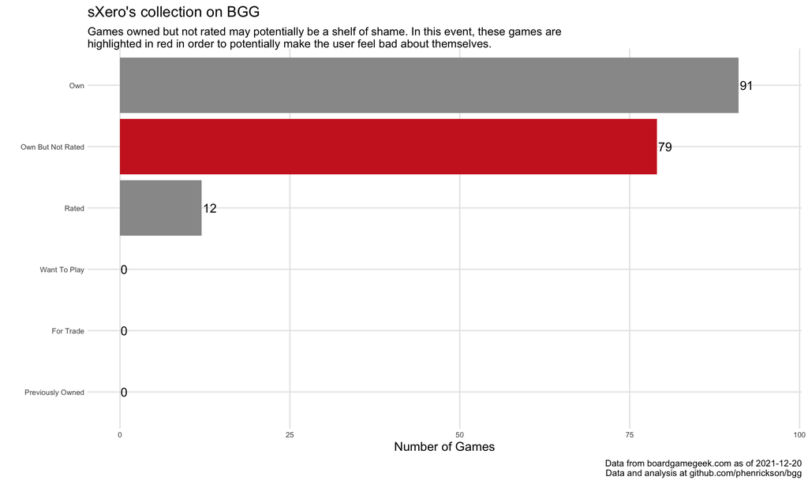

What years has the user owned/rated games from? While we can’t see when a user added or removed a game from their collection, we can look at their collection by the years in which their games were published.

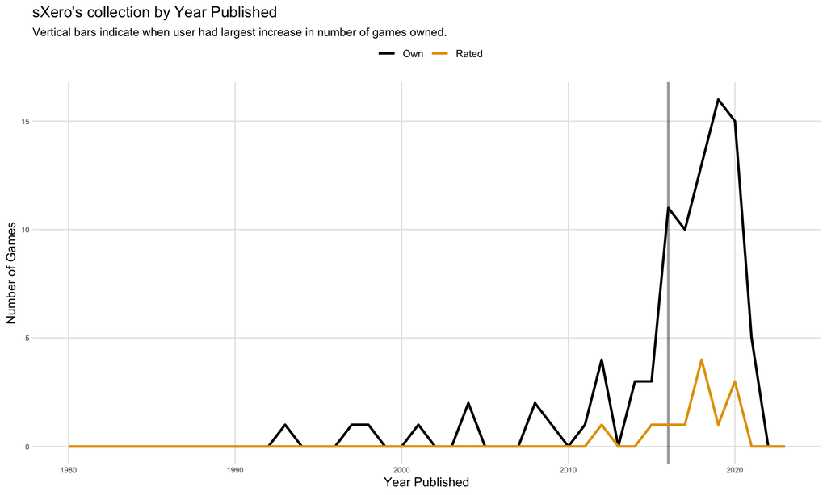

## 1.1 What types of games does sXero own?

We can look at the most frequent types of categories, mechanics, designers, and artists that appear in a user’s collection.

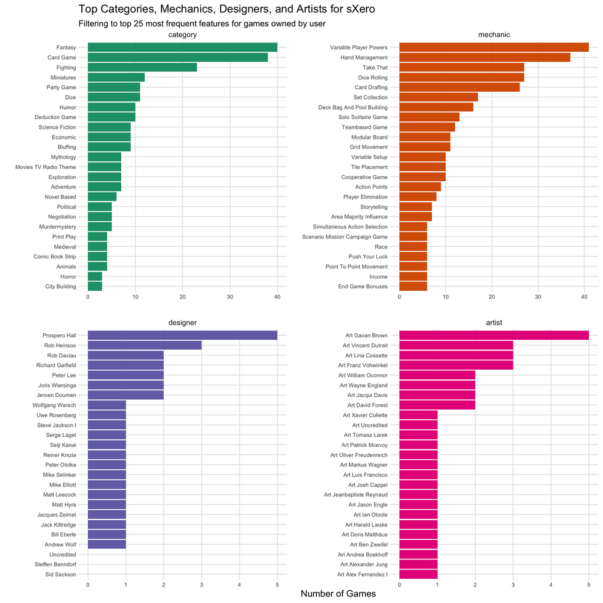

# 2 Modeling **sXero’s** Collection

| username | dataset | period | games_owned | games_rated | games_played |
| --- | --- | --- | --- | --- | --- |
| sXero | training | published before 2020 | 70 | 9 | 70 |
| sXero | test | published 2020 or later | 20 | 3 | 20 |

There are two main (binary) outcomes we will be modeling for the user.

The first, **own** refers to whether the user currently lists a game as owned in their collection. The second, **played** refers to whether the user currently owns, has rated, or previously owned a game. This means the latter will generally have a larger list of games, but may still be a useful category to examine for people who play lots of games without necessarily owning them.

We will train predictive models to learn the probability that the user will own or play individual games based on their features.

## 2.1 Coefficients for sXero

We can examine coefficients from the trained modes, which are penalized logistic regressions fit to our two main outcomes. Positive values indicate that a feature increases a user’s probabilility of owning/rating a game, while negative values indicate a feature decreases the probability.

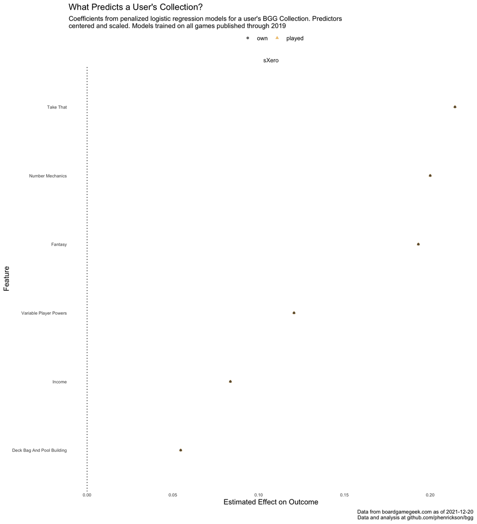

## 2.2 Visualizing Predictors for sXero’s Collection

Why did the model identify these features? We can make density plots of the important features for predicting whether the user owned a game. Blue indicates the density for games owned by the user, while grey indicates the density for games not owned by the user.

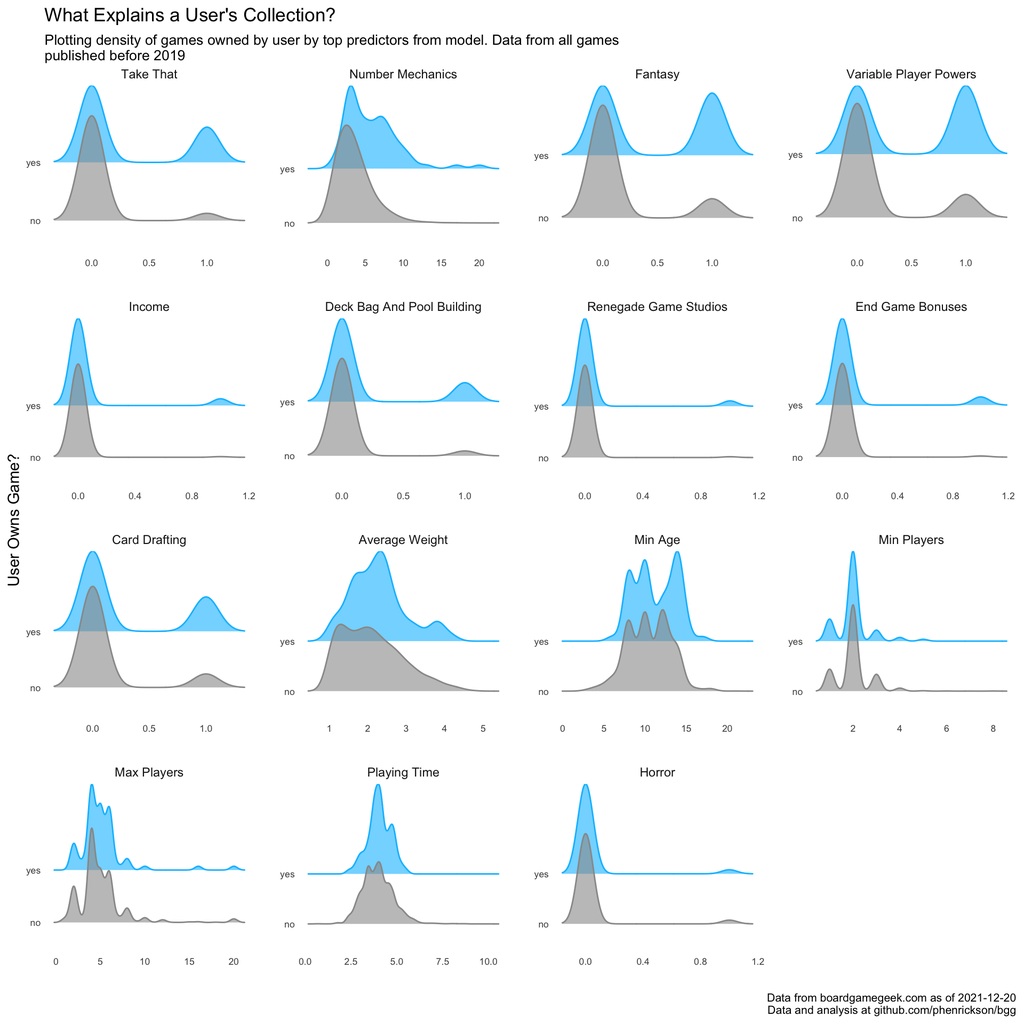

Binary predictors can be difficult to see with this visualization, so we can also directly examine the percentage of games in a user’s collection with a predictor vs the percentage of all games with that predictor.

| username | Feature | % of Games with Feature In_Collection | % of Games with Feature All_Games | Ratio |
| --- | --- | --- | --- | --- |
| sXero | Income | 7.1% | 0.7% | 10.5 |
| sXero | End Game Bonuses | 8.6% | 1.2% | 6.9 |
| sXero | Renegade Game Studios | 5.7% | 0.9% | 6.7 |
| sXero | Take That | 31.4% | 6.5% | 4.9 |
| sXero | Deck Bag And Pool Building | 18.6% | 4.8% | 3.9 |
| sXero | Fantasy | 47.1% | 14.5% | 3.2 |
| sXero | Variable Player Powers | 50.0% | 16.8% | 3.0 |
| sXero | Prehistoric | 2.9% | 1.0% | 2.8 |
| sXero | Card Drafting | 30.0% | 11.8% | 2.5 |
| sXero | Mafia | 1.4% | 0.7% | 2.0 |
| sXero | Negotiation | 5.7% | 3.6% | 1.6 |
| sXero | Murdermystery | 2.9% | 1.8% | 1.6 |
| sXero | Party Game | 12.9% | 8.4% | 1.5 |
| sXero | Deduction Game | 8.6% | 6.4% | 1.3 |
| sXero | Horror | 4.3% | 4.0% | 1.1 |
| sXero | City Building | 4.3% | 4.3% | 1.0 |
| sXero | Word Game | 1.4% | 1.8% | 0.8 |
| sXero | Trivia | 1.4% | 1.8% | 0.8 |
| sXero | Medieval | 4.3% | 6.4% | 0.7 |
| sXero | Realtime | 2.9% | 4.2% | 0.7 |
| sXero | Trains | 1.4% | 2.2% | 0.6 |
| sXero | Racing | 1.4% | 2.8% | 0.5 |
| sXero | Puzzle | 1.4% | 3.4% | 0.4 |
| sXero | Action Dexterity | 1.4% | 4.8% | 0.3 |
| sXero | Sports | 0.0% | 2.0% | 0.0 |

# 3 Assess Model’s Performance on Training Set

Before predicting games in upcoming years, we can examine how well the model did and what games it liked in the training set. In this case, we used resampling techniques (cross validation) to ensure that the model had not seen a game before making its predictions.

## 3.1 Separation Plot

An easy way to examine the performance of classification model is to view a separation plot. We plot the predicted probabilities from the model for every game (from resampling) from lowest to highest. We then overlay a blue line for any game that the user does own. A good classifier is one that is able to *separate* the blue (games owned by the user) from the white (games not owned by the user), with most of the blue occurring at the highest probabilities (right side of the chart).

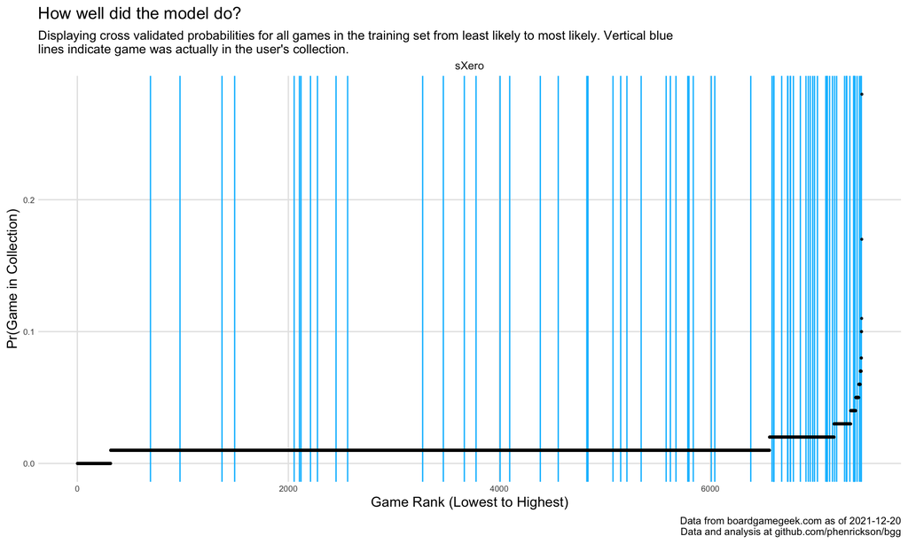

## 3.2 Top Games for **sXero** from Training Set

We can display this information in table form, displaying the 100 games with the highest probability of ownership, adding a blue line when the user does own the game.

| username | yearpublished | game_id | name | pred_played | pred_own | actual_played | actual_own |
| --- | --- | --- | --- | --- | --- | --- | --- |
| sXero | 2018 | 205896 | Rising Sun | 0.28 | 0.28 | 0 | 0 |
| sXero | 2014 | 157354 | Five Tribes | 0.17 | 0.17 | 0 | 0 |
| sXero | 2010 | 62219 | Dominant Species | 0.11 | 0.11 | 0 | 0 |
| sXero | 2019 | 276025 | Maracaibo | 0.10 | 0.10 | 0 | 0 |
| sXero | 2012 | 120677 | Terra Mystica | 0.10 | 0.10 | 0 | 0 |
| sXero | 2019 | 270971 | Era: Medieval Age | 0.08 | 0.08 | 0 | 0 |
| sXero | 2016 | 167791 | Terraforming Mars | 0.08 | 0.08 | 1 | 1 |
| sXero | 2019 | 274638 | Unmatched: Robin Hood vs. Bigfoot | 0.07 | 0.07 | 0 | 0 |
| sXero | 2018 | 244711 | Newton | 0.07 | 0.07 | 0 | 0 |
| sXero | 2017 | 193728 | Pendragon: The Fall of Roman Britain | 0.07 | 0.07 | 0 | 0 |
| sXero | 2017 | 220308 | Gaia Project | 0.07 | 0.07 | 0 | 0 |
| sXero | 2013 | 124548 | The Doom That Came to Atlantic City | 0.07 | 0.07 | 0 | 0 |
| sXero | 2019 | 274637 | Unmatched: Battle of Legends, Volume One | 0.07 | 0.07 | 1 | 1 |
| sXero | 2012 | 128780 | Pax Porfiriana | 0.07 | 0.07 | 0 | 0 |
| sXero | 2016 | 182351 | Thief's Market | 0.07 | 0.07 | 0 | 0 |
| sXero | 2011 | 88408 | Nightfall | 0.07 | 0.07 | 0 | 0 |
| sXero | 2018 | 222219 | Kero | 0.06 | 0.06 | 0 | 0 |
| sXero | 1980 | 4746 | Dungeons & Dragons Computer Labyrinth Game | 0.06 | 0.06 | 0 | 0 |
| sXero | 2012 | 104710 | Wiz-War (Eighth Edition) | 0.06 | 0.06 | 0 | 0 |
| sXero | 2019 | 295564 | Unmatched Game System | 0.06 | 0.06 | 0 | 0 |
| sXero | 1995 | 13 | Catan | 0.06 | 0.06 | 0 | 0 |
| sXero | 2015 | 168582 | Dragon Racer | 0.06 | 0.06 | 0 | 0 |
| sXero | 2017 | 174430 | Gloomhaven | 0.06 | 0.06 | 1 | 1 |
| sXero | 2015 | 175878 | 504 | 0.06 | 0.06 | 0 | 0 |
| sXero | 2019 | 251247 | Barrage | 0.06 | 0.06 | 0 | 0 |
| sXero | 2016 | 195518 | Crazy Karts | 0.06 | 0.06 | 0 | 0 |
| sXero | 2014 | 149097 | Spurs: A Tale in the Old West | 0.06 | 0.06 | 0 | 0 |
| sXero | 2019 | 280480 | Crystal Palace | 0.06 | 0.06 | 0 | 0 |
| sXero | 2016 | 131111 | Codex: Card-Time Strategy – Deluxe Set | 0.06 | 0.06 | 0 | 0 |
| sXero | 2014 | 148951 | Tiny Epic Kingdoms | 0.06 | 0.06 | 0 | 0 |

[output cut: 70 more lines]

We can also more formally assess how well the model did in resampling by looking at the area under the receiver operating characteristic. A perfect model would receive a score of 1, while a model that cannot predict the outcome will default to a score of 0.5. The extent to which something is a *good* score depends on the setting, but generally anything in the .8 to .9 range is very good while the .7 to .8 range is perfectly acceptable.

| username | outcome_type | .metric | .estimator | .estimate |
| --- | --- | --- | --- | --- |
| sXero | own | roc_auc | binary | 0.803 |
| sXero | played | roc_auc | binary | 0.803 |

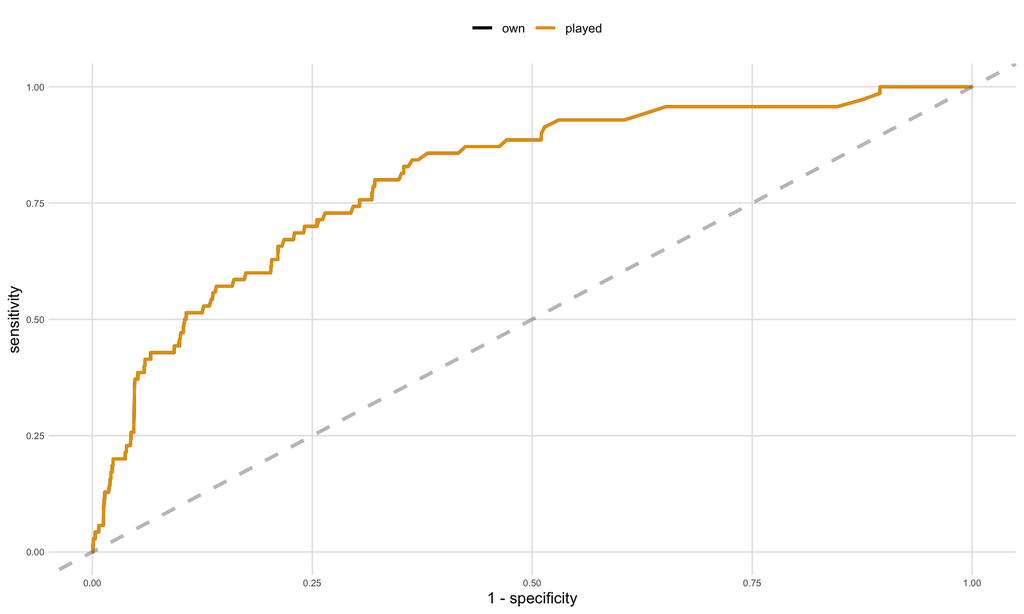

Another way to think about the model performance is to view its lift, or its ability to detect the positive outcomes over that of a null model. High lift indicates the model can much more quickly find all of the positive outcomes (in this case, games owned or played by the user), while a model with no lift is no better than random guessing.

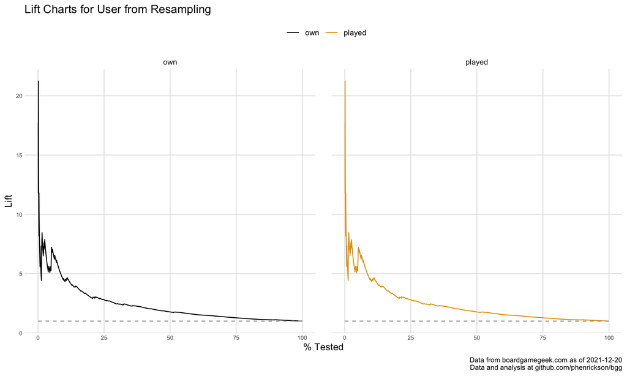

## 3.3 Most and Least Likely Games

What games does the model think sXero is **most likely to own** that are **not** in their collection?

| username | yearpublished | game_id | name | pred_own | actual_own |
| --- | --- | --- | --- | --- | --- |
| sXero | 2018 | 205896 | Rising Sun | 0.28 | 0 |
| sXero | 2014 | 157354 | Five Tribes | 0.17 | 0 |
| sXero | 2010 | 62219 | Dominant Species | 0.11 | 0 |
| sXero | 2019 | 276025 | Maracaibo | 0.10 | 0 |
| sXero | 2012 | 120677 | Terra Mystica | 0.10 | 0 |

What games does the model think sXero is **least likely to own** that **are** in their collection?

| username | yearpublished | game_id | name | pred_own | actual_own |
| --- | --- | --- | --- | --- | --- |
| sXero | 2019 | 285905 | Marvel: Crisis Protocol | 0.01 | 1 |
| sXero | 2019 | 275916 | Cairn | 0.01 | 1 |
| sXero | 1948 | 320 | Scrabble | 0.01 | 1 |
| sXero | 2016 | 169426 | Roll Player | 0.01 | 1 |
| sXero | 2017 | 217372 | The Quest for El Dorado | 0.01 | 1 |

## 3.4 Top Games by Year

Top 25 games most likely to be owned by the user in each year, highlighting in blue the games that the user has owned/played.

| rank | 2011 | 2012 | 2013 | 2014 | 2015 | 2016 | 2017 | 2018 | 2019 |
| --- | --- | --- | --- | --- | --- | --- | --- | --- | --- |
| 1 | Nightfall | Terra Mystica | The Doom That Came to Atlantic City | Five Tribes | Dragon Racer | Terraforming Mars | Pendragon: The Fall of Roman Britain | Rising Sun | Maracaibo |
| 2 | Dungeon Raiders | Pax Porfiriana | Smash Up: Awesome Level 9000 | Spurs: A Tale in the Old West | 504 | Thief's Market | Gaia Project | Newton | Era: Medieval Age |
| 3 | Space Empires: 4X | Wiz-War (Eighth Edition) | Munchkin Pathfinder | Tiny Epic Kingdoms | Dale of Merchants | Crazy Karts | Gloomhaven | Kero | Unmatched: Robin Hood vs. Bigfoot |
| 4 | Mage Knight Board Game | Smash Up | Friese's Landlord | Smash Up: Science Fiction Double Feature | Through the Ages: A New Story of Civilization | Codex: Card-Time Strategy – Deluxe Set | Smash Up: What Were We Thinking? | Everdell | Unmatched: Battle of Legends, Volume One |
| 5 | Discworld: Ankh-Morpork | Kill the Overlord | Firefly: The Game | Smash Up: Monster Smash | The Voyages of Marco Polo | Smash Up: Cease and Desist | Breaking Bad: The Board Game | Western Legends | Unmatched Game System |
| 6 | Octopus's Garden | War of the Ring: Second Edition | Boss Monster: The Dungeon Building Card Game | Sons of Anarchy: Men of Mayhem | Tiny Epic Galaxies | Dale of Merchants 2 | The Godfather: Corleone's Empire | Heroes of Land, Air & Sea | Barrage |
| 7 | Dungeon Fighter | Il Vecchio | Pathfinder Adventure Card Game: Rise of the Runelords – Base Set | Alchemists | Dragon Farkle | Mansions of Madness: Second Edition | Covil: The Dark Overlords | Off the Rails | Crystal Palace |
| 8 | A Game of Thrones: The Board Game (Second Edition) | Seasons | Tash-Kalar: Arena of Legends | Colt Express | Raptor | 13 Days: The Cuban Missile Crisis | Summit: The Board Game | Boss Monster: Rise of the Minibosses | Tiny Epic Tactics |
| 9 | Pergamemnon | Exodus: Proxima Centauri | City of Iron | Patchwork | Grand Austria Hotel | Exceed Fighting System | Betrayal at Baldur's Gate | Disney Villainous | Clank!: Legacy – Acquisitions Incorporated |
| 10 | Omen: A Reign of War | Epic Spell Wars of the Battle Wizards: Duel at Mt. Skullzfyre | Tomorrow | Fields of Arle | Titan Race | Gorechosen | Masmorra: Dungeons of Arcadia | Dead Man's Doubloons | Dungeonology: The Expedition |
| 11 | Drako: Dragon & Dwarves | Archipelago | LEADERS: The Combined Strategy Game | Star Realms | Munchkin Oz | Aeon's End | Rick and Morty: Close Rick-Counters of the Rick Kind Deck-Building Game | Dice Throne: Season Two – Battle Chest | Tapestry |
| 12 | Summoner Wars: Master Set | The Manhattan Project | Munchkin Legends | Pathfinder Adventure Card Game: Skull & Shackles – Base Set | Ylandyss | Hero Realms | Mistborn: House War | Carthage | The Magnificent |
| 13 | Rune Age | Descent: Journeys in the Dark (Second Edition) | Forbidden Desert | Imperial Settlers | The Pursuit of Happiness | Pathfinder Adventure Card Game: Mummy's Mask – Base Set | InBetween | Too Many Bones: Undertow | Dale of Merchants Collection |
| 14 | Penny Arcade: The Game – Gamers vs. Evil | Lords of Waterdeep | Concordia | Arcadia Quest | Runebound (Third Edition) | One Deck Dungeon | Fate of the Elder Gods | Smash Up: Oops, You Did It Again | Tiny Epic Mechs |
| 15 | TSCHAK! | Kings of War | BattleLore: Second Edition | Black Fleet | Risk: Europe | Sakura Arms | Photosynthesis | Dice Throne: Season Two – Tactician v. Huntress | Aquatica |
| 16 | Quarriors! | Mage Wars Arena | Pixel Tactics 2 | Mythotopia | The Bloody Inn | Covert | Too Many Bones | Castle Rampage | Tainted Grail: The Fall of Avalon |
| 17 | Trajan | Neuroshima: Convoy | Smash Up: The Obligatory Cthulhu Set | Ca$h 'n Guns (Second Edition) | Smash Up: Munchkin | Karmaka | Path of Light and Shadow | The Edge: Dawnfall | Disney Villainous: Wicked to the Core |
| 18 | Elder Sign | Ascension: Immortal Heroes | Ascension: Darkness Unleashed | Shadows of Malice | Gingerdead House | Dwar7s Fall | Wendake | Root | Disney Villainous: Evil Comes Prepared |
| 19 | Ultimate Warriorz | Pixel Tactics | Ascension: Apprentice Edition | Ultimate Werewolf | Potion Explosion | Guildhall Fantasy: Alliance | Fast Forward: FORTRESS | The City of Kings | Dune |
| 20 | Chaostle | Equinox | City of Remnants | Marrying Mr. Darcy | Epic Card Game | Guildhall Fantasy: Fellowship | Import / Export | Star Scrappers: Cave-in | Ancient Civilizations of the Inner Sea |
| 21 | Eclipse | Mice and Mystics | Asgard's Chosen | Hyperborea | Heroes | Flag Dash | Dragonfire | The Grimm Forest | It's a Wonderful World |
| 22 | Pirate Fluxx | Tzolk'in: The Mayan Calendar | Warhammer: Diskwars | Munchkin Adventure Time | The Lord of the Rings: Journey to Mordor | Behind the Throne | Apocrypha Adventure Card Game: Box One – The World | Enchanters: Overlords | Blitzkrieg!: World War Two in 20 Minutes |
| 23 | Villages | Legends of Andor | Legacy: The Testament of Duke de Crecy | Student Bodies | Nevermore | Forged in Steel | My Little Scythe | Underwater Cities | Siege Storm |
| 24 | Munchkin Axe Cop | Might & Magic Heroes | Berserk: War of the Realms | Draco Magi | Karnivore Koala | Islebound | Epic Spell Wars of the Battle Wizards: Melee at Murdershroom Marsh | Star Realms: Frontiers | Spire's End |
| 25 | Dreadfleet | Spartacus: A Game of Blood and Treachery | The Red Dragon Inn 4 | Castles of Mad King Ludwig | Super Dungeon Explore: Forgotten King | Mistfall: Heart of the Mists | Quests of Valeria | Shards of Infinity | Black Rose Wars |

## 3.5 Interactive Predictions from Resampling

Interactive table for predictions from resampling.

|  | username | yearpublished | rank | game_id | name | pred_played | pred_own | actual_played | actual_own |
| --- | --- | --- | --- | --- | --- | --- | --- | --- | --- |
| 1 | sXero | 1900 | 705 | 6424 | Pick Up Sticks | 0.02 | 0.02 | 0 | 0 |
| 2 | sXero | 1900 | 887 | 5546 | Marbles | 0.01 | 0.01 | 0 | 0 |
| 3 | sXero | 1900 | 890 | 11901 | Tic-Tac-Toe | 0.01 | 0.01 | 0 | 0 |
| 4 | sXero | 1900 | 934 | 188 | Go | 0.01 | 0.01 | 0 | 0 |
| 5 | sXero | 1900 | 1040 | 171 | Chess | 0.01 | 0.01 | 0 | 0 |
| 6 | sXero | 1900 | 1050 | 2065 | Shogi | 0.01 | 0.01 | 0 | 0 |
| 7 | sXero | 1900 | 1052 | 2393 | Xiangqi | 0.01 | 0.01 | 0 | 0 |
| 8 | sXero | 1900 | 1258 | 26952 | International Checkers | 0.01 | 0.01 | 0 | 0 |
| 9 | sXero | 1900 | 1285 | 1602 | The Royal Game of Ur | 0.01 | 0.01 | 0 | 0 |
| 10 | sXero | 1900 | 1286 | 2083 | Checkers | 0.01 | 0.01 | 0 | 0 |

[output cut: 7426 more lines]

# 4 Validating the Model on 2020

How well did a model trained on a user’s collection through 2019 perform in predicting games for the user from 2020?

| username | outcome_type | yearpublished | .metric | .estimator | .estimate |
| --- | --- | --- | --- | --- | --- |
| sXero | own | 2020 | roc_auc | binary | 0.639 |
| sXero | played | 2020 | roc_auc | binary | 0.639 |

Table of top 25 games from 2020, highlighting games that the user owns.

| username | yearpublished | game_id | name | pred_own | pred_played | actual_own | actual_played |
| --- | --- | --- | --- | --- | --- | --- | --- |
| sXero | 2020 | 256317 | Guild Master | 0.32 | 0.32 | 0 | 0 |
| sXero | 2020 | 295577 | Dungeon Mayhem: Monster Madness | 0.10 | 0.10 | 1 | 1 |
| sXero | 2020 | 302465 | Obsidia | 0.08 | 0.08 | 0 | 0 |
| sXero | 2020 | 262274 | D6: Dungeons, Dudes, Dames, Danger, Dice and Dragons! | 0.07 | 0.07 | 0 | 0 |
| sXero | 2020 | 305270 | Chronicles of Waral | 0.07 | 0.07 | 0 | 0 |
| sXero | 2020 | 184267 | On Mars | 0.06 | 0.06 | 0 | 0 |
| sXero | 2020 | 246900 | Eclipse: Second Dawn for the Galaxy | 0.06 | 0.06 | 0 | 0 |
| sXero | 2020 | 294484 | Unmatched: Cobble & Fog | 0.06 | 0.06 | 0 | 0 |
| sXero | 2020 | 299252 | Here to Slay | 0.06 | 0.06 | 0 | 0 |
| sXero | 2020 | 315060 | Unmatched: Buffy the Vampire Slayer | 0.06 | 0.06 | 0 | 0 |
| sXero | 2020 | 282544 | Video Vortex | 0.05 | 0.05 | 0 | 0 |
| sXero | 2020 | 284777 | Unmatched: Jurassic Park – InGen vs Raptors | 0.05 | 0.05 | 0 | 0 |
| sXero | 2020 | 291457 | Gloomhaven: Jaws of the Lion | 0.05 | 0.05 | 0 | 0 |
| sXero | 2020 | 312346 | Munchkin Disney | 0.05 | 0.05 | 0 | 0 |
| sXero | 2020 | 325635 | Unmatched: Little Red Riding Hood vs. Beowulf | 0.05 | 0.05 | 0 | 0 |
| sXero | 2020 | 236713 | Sea of Plunder | 0.04 | 0.04 | 0 | 0 |
| sXero | 2020 | 265575 | Materia Prima: The Alchemists Guild | 0.04 | 0.04 | 0 | 0 |
| sXero | 2020 | 276801 | Valhallamas | 0.04 | 0.04 | 0 | 0 |
| sXero | 2020 | 289850 | Dwar7s Spring | 0.04 | 0.04 | 0 | 0 |
| sXero | 2020 | 289939 | Goblin Teeth | 0.04 | 0.04 | 0 | 0 |
| sXero | 2020 | 291794 | Dice Throne: Season One ReRolled | 0.04 | 0.04 | 0 | 0 |
| sXero | 2020 | 299452 | Dale of Merchants 3 | 0.04 | 0.04 | 0 | 0 |
| sXero | 2020 | 300322 | Hallertau | 0.04 | 0.04 | 0 | 0 |
| sXero | 2020 | 313850 | Escape The Night: The Board Game | 0.04 | 0.04 | 0 | 0 |
| sXero | 2020 | 316554 | Dune: Imperium | 0.04 | 0.04 | 1 | 1 |

# 5 Predicting Upcoming Games (2020 and On) for **sXero**

Examine the top games for the test set.

| username | yearpublished | game_id | name | rank | own | played |
| --- | --- | --- | --- | --- | --- | --- |
| sXero | 2020 | 256317 | Guild Master | 1 | 0.32 | 0.32 |
| sXero | 2020 | 295577 | Dungeon Mayhem: Monster Madness | 2 | 0.10 | 0.10 |
| sXero | 2020 | 302465 | Obsidia | 3 | 0.08 | 0.08 |
| sXero | 2020 | 262274 | D6: Dungeons, Dudes, Dames, Danger, Dice and Dragons! | 4 | 0.07 | 0.07 |
| sXero | 2020 | 305270 | Chronicles of Waral | 5 | 0.07 | 0.07 |
| sXero | 2020 | 294484 | Unmatched: Cobble & Fog | 6 | 0.06 | 0.06 |
| sXero | 2020 | 315060 | Unmatched: Buffy the Vampire Slayer | 7 | 0.06 | 0.06 |
| sXero | 2020 | 246900 | Eclipse: Second Dawn for the Galaxy | 8 | 0.06 | 0.06 |
| sXero | 2020 | 184267 | On Mars | 9 | 0.06 | 0.06 |
| sXero | 2020 | 299252 | Here to Slay | 10 | 0.06 | 0.06 |
| sXero | 2020 | 312346 | Munchkin Disney | 11 | 0.05 | 0.05 |
| sXero | 2020 | 282544 | Video Vortex | 12 | 0.05 | 0.05 |
| sXero | 2020 | 291457 | Gloomhaven: Jaws of the Lion | 13 | 0.05 | 0.05 |
| sXero | 2020 | 284777 | Unmatched: Jurassic Park – InGen vs Raptors | 14 | 0.05 | 0.05 |
| sXero | 2020 | 325635 | Unmatched: Little Red Riding Hood vs. Beowulf | 15 | 0.05 | 0.05 |
| sXero | 2020 | 236713 | Sea of Plunder | 16 | 0.04 | 0.04 |
| sXero | 2020 | 291794 | Dice Throne: Season One ReRolled | 17 | 0.04 | 0.04 |
| sXero | 2020 | 313850 | Escape The Night: The Board Game | 18 | 0.04 | 0.04 |
| sXero | 2020 | 300322 | Hallertau | 19 | 0.04 | 0.04 |
| sXero | 2020 | 276801 | Valhallamas | 20 | 0.04 | 0.04 |
| sXero | 2020 | 289850 | Dwar7s Spring | 21 | 0.04 | 0.04 |
| sXero | 2020 | 289939 | Goblin Teeth | 22 | 0.04 | 0.04 |
| sXero | 2020 | 299452 | Dale of Merchants 3 | 23 | 0.04 | 0.04 |
| sXero | 2020 | 265575 | Materia Prima: The Alchemists Guild | 24 | 0.04 | 0.04 |
| sXero | 2020 | 316554 | Dune: Imperium | 25 | 0.04 | 0.04 |
| sXero | 2021 | 320446 | Corduba 27 a.C. | 1 | 0.09 | 0.09 |
| sXero | 2021 | 335764 | Unmatched: Battle of Legends, Volume Two | 2 | 0.06 | 0.06 |
| sXero | 2021 | 310873 | Carnegie | 3 | 0.06 | 0.06 |
| sXero | 2021 | 298383 | Golem | 4 | 0.05 | 0.05 |
| sXero | 2021 | 342942 | Ark Nova | 5 | 0.05 | 0.05 |
| sXero | 2021 | 277080 | Titans | 6 | 0.05 | 0.05 |
| sXero | 2021 | 322561 | Dice Throne: Season One ReRolled – Barbarian v. Moon Elf | 7 | 0.04 | 0.04 |
| sXero | 2021 | 322562 | Dice Throne: Season One ReRolled – Monk v. Paladin | 8 | 0.04 | 0.04 |
| sXero | 2021 | 322563 | Dice Throne: Season One ReRolled – Pyromancer v. Shadow Thief | 9 | 0.04 | 0.04 |
| sXero | 2021 | 340237 | Wonder Book | 10 | 0.04 | 0.04 |
| sXero | 2021 | 295535 | Dark Ages: Heritage of Charlemagne | 11 | 0.04 | 0.04 |
| sXero | 2021 | 304985 | Dark Ages: Holy Roman Empire | 12 | 0.04 | 0.04 |
| sXero | 2021 | 301366 | Caves of Rwenzori | 13 | 0.04 | 0.04 |
| sXero | 2021 | 310641 | Ostium | 14 | 0.04 | 0.04 |
| sXero | 2021 | 251661 | Oathsworn: Into the Deepwood | 15 | 0.04 | 0.04 |
| sXero | 2021 | 332800 | Summoner Wars (Second Edition) | 16 | 0.04 | 0.04 |
| sXero | 2021 | 333348 | Dirge: The Rust Wars | 17 | 0.04 | 0.04 |
| sXero | 2021 | 339263 | Summoner Wars (Second Edition): Starter Set | 18 | 0.04 | 0.04 |
| sXero | 2021 | 343905 | Boonlake | 19 | 0.04 | 0.04 |
| sXero | 2021 | 211364 | Seize the Bean | 20 | 0.03 | 0.03 |
| sXero | 2021 | 331212 | Aeon's End: Legacy of Gravehold | 21 | 0.03 | 0.03 |
| sXero | 2021 | 291572 | Oath: Chronicles of Empire and Exile | 22 | 0.03 | 0.03 |
| sXero | 2021 | 273330 | Bloodborne: The Board Game | 23 | 0.03 | 0.03 |
| sXero | 2021 | 282700 | LOOP: Life of Ordinary People | 24 | 0.03 | 0.03 |
| sXero | 2021 | 298102 | Roll Camera!: The Filmmaking Board Game | 25 | 0.03 | 0.03 |
| sXero | 2022 | 295770 | Frosthaven | 1 | 0.06 | 0.06 |
| sXero | 2022 | 331106 | The Witcher: Old World | 2 | 0.05 | 0.05 |
| sXero | 2022 | 273814 | Deliverance | 3 | 0.04 | 0.04 |
| sXero | 2022 | 330950 | Age of Galaxy | 4 | 0.04 | 0.04 |
| sXero | 2022 | 322524 | Bardsung | 5 | 0.04 | 0.04 |
| sXero | 2022 | 342444 | Black Rose Wars: Rebirth | 6 | 0.03 | 0.03 |
| sXero | 2022 | 281258 | Sub Terra II: Inferno's Edge | 7 | 0.03 | 0.03 |
| sXero | 2022 | 311823 | Nova Aetas Renaissance | 8 | 0.03 | 0.03 |
| sXero | 2022 | 256680 | Return to Dark Tower | 9 | 0.03 | 0.03 |
| sXero | 2022 | 320718 | Hidden Leaders | 10 | 0.03 | 0.03 |
| sXero | 2022 | 317321 | Darkest Dungeon: The Board Game | 11 | 0.03 | 0.03 |
| sXero | 2022 | 319910 | Pagan: Fate of Roanoke | 12 | 0.02 | 0.02 |
| sXero | 2022 | 336986 | Flamecraft | 13 | 0.02 | 0.02 |
| sXero | 2022 | 299106 | Fractal: Beyond the Void | 14 | 0.02 | 0.02 |
| sXero | 2022 | 227935 | Wonderland's War | 15 | 0.02 | 0.02 |
| sXero | 2022 | 339592 | Sheep in Disguise | 16 | 0.02 | 0.02 |
| sXero | 2022 | 333255 | Keep the Heroes Out! | 17 | 0.02 | 0.02 |
| sXero | 2022 | 338067 | 6: Siege – The Board Game | 18 | 0.02 | 0.02 |
| sXero | 2022 | 294529 | Entropia: The Game | 19 | 0.02 | 0.02 |
| sXero | 2022 | 342246 | Feuding Foodies | 20 | 0.02 | 0.02 |
| sXero | 2022 | 303731 | Primal: The Awakening | 21 | 0.02 | 0.02 |
| sXero | 2022 | 283137 | Human Punishment: The Beginning | 22 | 0.02 | 0.02 |
| sXero | 2022 | 280726 | Legacies | 23 | 0.02 | 0.02 |
| sXero | 2022 | 267609 | Guards of Atlantis II: Tabletop MOBA | 24 | 0.02 | 0.02 |
| sXero | 2022 | 275284 | Arkeis | 25 | 0.02 | 0.02 |

## 5.1 Interactive Table for Upcoming Games 2020 and On

|  | username | yearpublished | game_id | name | rank | own | played |
| --- | --- | --- | --- | --- | --- | --- | --- |
| 1 | sXero | 2020 | 256317 | Guild Master | 1 | 0.32 | 0.32 |
| 2 | sXero | 2020 | 295577 | Dungeon Mayhem: Monster Madness | 2 | 0.1 | 0.1 |
| 3 | sXero | 2021 | 320446 | Corduba 27 a.C. | 3 | 0.09 | 0.09 |
| 4 | sXero | 2020 | 302465 | Obsidia | 4 | 0.08 | 0.08 |
| 5 | sXero | 2020 | 262274 | D6: Dungeons, Dudes, Dames, Danger, Dice and Dragons! | 5 | 0.07 | 0.07 |
| 6 | sXero | 2020 | 305270 | Chronicles of Waral | 6 | 0.07 | 0.07 |
| 7 | sXero | 2022 | 295770 | Frosthaven | 7 | 0.06 | 0.06 |
| 8 | sXero | 2020 | 294484 | Unmatched: Cobble &amp; Fog | 8 | 0.06 | 0.06 |
| 9 | sXero | 2020 | 315060 | Unmatched: Buffy the Vampire Slayer | 9 | 0.06 | 0.06 |
| 10 | sXero | 2021 | 335764 | Unmatched: Battle of Legends, Volume Two | 10 | 0.06 | 0.06 |

[output cut: 1627 more lines]